# First Pass Markdown

Lib

30/07/2020

```r
#Set seed for random number generation
set.seed(42)
knitr::opts_chunk$set(cache.extra = knitr::rand_seed)
```

# Research Questions

As readers do we predict upcoming information before it is encountered in order to better understand the unfolding discourse?

If prediction is not utilized do we rely on more on basic integration to understand an unfolding discourse context?

Do individual differences contribute to our ability to predict and/or integrate upcoming information? How do these contribute?

# Region 4: The question

Let’s have a look at various models for our critical region of interest, the question.

```r
#Let's have a look at region 4

#set condition as a factor
all_data_join$cond <- as.factor(all_data_join$cond)
# Throw away zeroes
all_data_join <- all_data_join %>% filter(R4 != 0)
```

## Eye-tracking only model

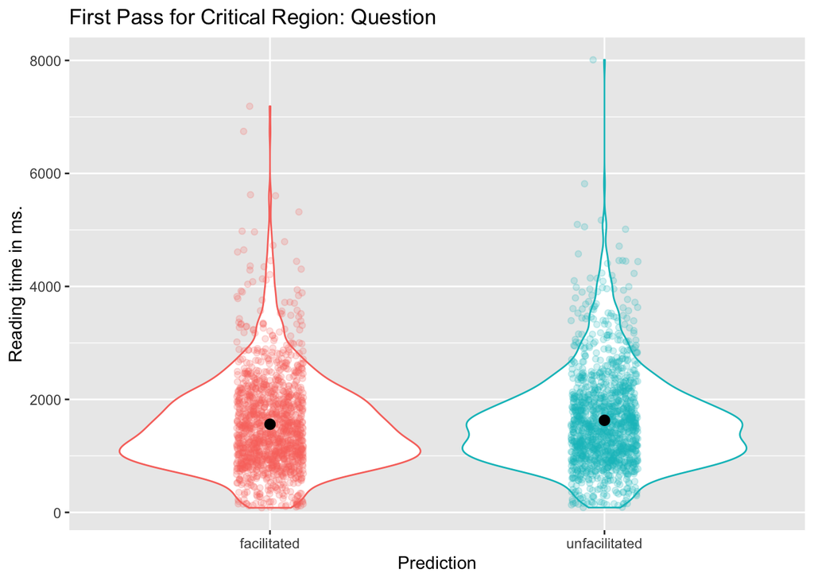

```r
#Let's have a look at region 4

#set condition as a factor
all_data_join$cond <- as.factor(all_data_join$cond)
# Throw away zeroes
all_data_join <- all_data_join %>% filter(R4 != 0)

#Visualisation
all_data_join %>%
  ggplot(aes(x = cond, y = R4, colour = cond)) + ggtitle("First Pass for Critical Region: Question") +
  labs(y = "Reading time in ms.", x = "Prediction") +
  geom_violin() +
  geom_jitter(alpha = .2, width = .1) +
  stat_summary(fun.data = "mean_cl_boot", colour = "black") +
  guides(colour = FALSE)
```

```r
#Descriptives
all_data_join %>%
  group_by(cond) %>%
  summarise(mean(R4), sd(R4))
```

```
## # A tibble: 2 x 3
##   cond          `mean(R4)` `sd(R4)`
##   <fct>              <dbl>    <dbl>
## 1 facilitated        1560.     850.
## 2 unfacilitated      1631.     855.
```

```r
# Model assuming normality of residuals maximal structure
#model.nullR4 <- lmer(R4 ~ (1 + cond | subj) + (1 + cond | item), all_data_join)
modelR4 <- lmer(R4 ~ cond + (1 + cond | subj) + (1 + cond | item), all_data_join)
summary(modelR4)
```

```
## Linear mixed model fit by REML. t-tests use Satterthwaite's method [
## lmerModLmerTest]
## Formula: R4 ~ cond + (1 + cond | subj) + (1 + cond | item)
##    Data: all_data_join
##
## REML criterion at convergence: 42545
##
## Scaled residuals:
##     Min      1Q  Median      3Q     Max
## -3.8439 -0.5228 -0.0949  0.4152  8.5471
##
## Random effects:
##  Groups   Name              Variance Std.Dev. Corr
##  subj     (Intercept)       265046.2 514.83
##           condunfacilitated    163.2  12.77   1.00
##  item     (Intercept)        52295.5 228.68
##           condunfacilitated  14636.8 120.98   -0.23
##  Residual                   405534.1 636.82
## Number of obs: 2680, groups:  subj, 84; item, 32
##
## Fixed effects:
##                   Estimate Std. Error      df t value Pr(>|t|)
## (Intercept)        1558.97      71.36   98.01  21.846   <2e-16 ***
## condunfacilitated    71.76      32.63   30.20   2.199   0.0357 *
## ---
## Signif. codes:  0 '***' 0.001 '**' 0.01 '*' 0.05 '.' 0.1 ' ' 1
##
## Correlation of Fixed Effects:
##             (Intr)
## condnfclttd -0.181
```

```r
#anova(modelR4, model.nullR4)

#All the data for this model looks pretty normal.
check_model(modelR4)
```

```
## Not enough model terms in the conditional part of the model to check for multicollinearity.
```

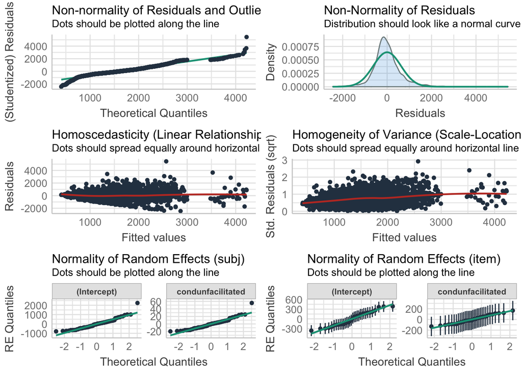

```r
#qqnorm(residuals(modelR4))
#qqline(residuals(modelR4))
#descdist(all_data_join$R4)
```

## Individual differences as controlling factors

```r
#Let's include some co-variates! Region 4

#Step 1: Scale the ID measures...
all_data_join$SRS_total_score_t <- scale(all_data_join$SRS_total_score_t)
all_data_join$EQ <- scale(all_data_join$EQ)
all_data_join$Total_reading_cluster <- scale(all_data_join$Total_reading_cluster)
all_data_join$Total_RAN <- scale(all_data_join$Total_RAN)
all_data_join$"WI _RPI" <- scale(all_data_join$"WI _RPI")
```

```r
# Model including covariates
model_alldatacov_R4 <- lmer(R4 ~ SRS_total_score_t + EQ + Total_reading_cluster + Total_RAN + cond + (1 | subj) +  (1 | item) , data = all_data_join, REML = TRUE)

#model_alldatacov_R4_null <- lmer(R4 ~ SRS_total_score_t + EQ + Total_reading_cluster + #Total_RAN +
#                               (1 + cond | subj) +  (1 + cond | item) , data = #all_data_join, REML = TRUE)

summary(model_alldatacov_R4)
```

```
## Linear mixed model fit by REML. t-tests use Satterthwaite's method [
## lmerModLmerTest]
## Formula: R4 ~ SRS_total_score_t + EQ + Total_reading_cluster + Total_RAN +
##     cond + (1 | subj) + (1 | item)
##    Data: all_data_join
##
## REML criterion at convergence: 41979.1
##
## Scaled residuals:
##     Min      1Q  Median      3Q     Max
## -3.9079 -0.5270 -0.0900  0.4172  8.5110
##
## Random effects:
##  Groups   Name        Variance Std.Dev.
##  subj     (Intercept) 259778   509.7
##  item     (Intercept)  48985   221.3
##  Residual             406596   637.6
## Number of obs: 2648, groups:  subj, 83; item, 32
##
## Fixed effects:
##                       Estimate Std. Error      df t value Pr(>|t|)
## (Intercept)            1558.90      70.49  107.45  22.117  < 2e-16 ***
## SRS_total_score_t       -31.39      73.27   77.99  -0.428  0.66954
## EQ                       13.38      73.34   77.98   0.182  0.85568
## Total_reading_cluster   -61.52      59.34   77.99  -1.037  0.30310
## Total_RAN               136.50      59.53   78.00   2.293  0.02454 *
## condunfacilitated        72.98      24.79 2533.12   2.945  0.00326 **
## ---
## Signif. codes:  0 '***' 0.001 '**' 0.01 '*' 0.05 '.' 0.1 ' ' 1
##
## Correlation of Fixed Effects:
##             (Intr) SRS___ EQ     Ttl_r_ Tt_RAN
## SRS_ttl_sc_ -0.001
## EQ           0.004  0.627
## Ttl_rdng_cl -0.007  0.008 -0.007
## Total_RAN   -0.001 -0.058 -0.056  0.263
## condnfclttd -0.176  0.000  0.000  0.000  0.000
```

So Total_RAN and our condition are significant.

If we drop the Total_RAN the effect of condition is still there (see below) - suggesting to me that the effect of Total_RAN is separate from the effect of condition.

```r
model_alldatacov_R4_noRAN <- lmer(R4 ~ SRS_total_score_t + EQ + Total_reading_cluster + cond + (1 | subj) +  (1 | item) , data = all_data_join, REML = TRUE)
summary(model_alldatacov_R4_noRAN)
```

```
## Linear mixed model fit by REML. t-tests use Satterthwaite's method [
## lmerModLmerTest]
## Formula: R4 ~ SRS_total_score_t + EQ + Total_reading_cluster + cond +
##     (1 | subj) + (1 | item)
##    Data: all_data_join
##
## REML criterion at convergence: 42517.4
##
## Scaled residuals:
##     Min      1Q  Median      3Q     Max
## -3.9247 -0.5294 -0.0957  0.4148  8.4923
##
## Random effects:
##  Groups   Name        Variance Std.Dev.
##  subj     (Intercept) 270843   520.4
##  item     (Intercept)  49791   223.1
##  Residual             409152   639.7
## Number of obs: 2680, groups:  subj, 84; item, 32
##
## Fixed effects:
##                       Estimate Std. Error      df t value Pr(>|t|)
## (Intercept)            1558.93      71.31  109.27  21.860  < 2e-16 ***
## SRS_total_score_t       -21.59      74.62   79.99  -0.289  0.77305
## EQ                       22.46      74.67   79.98   0.301  0.76433
## Total_reading_cluster   -96.75      58.19   79.98  -1.662  0.10033
## condunfacilitated        71.76      24.72 2564.31   2.903  0.00373 **
## ---
## Signif. codes:  0 '***' 0.001 '**' 0.01 '*' 0.05 '.' 0.1 ' ' 1
##
## Correlation of Fixed Effects:
##             (Intr) SRS___ EQ     Ttl_r_
## SRS_ttl_sc_  0.000
## EQ           0.000  0.627
## Ttl_rdng_cl  0.000  0.023  0.011
## condnfclttd -0.173  0.000  0.000  0.000
```

Does Total_RAN interact with our condition? No (see below.)

```r
model_alldatacov_R4_RAN_int <- lmer(R4 ~ SRS_total_score_t + EQ + Total_reading_cluster + Total_RAN + cond + cond:Total_RAN + (1 | subj) +  (1 | item) , data = all_data_join, REML = TRUE)
summary(model_alldatacov_R4_RAN_int)
```

```
## Linear mixed model fit by REML. t-tests use Satterthwaite's method [
## lmerModLmerTest]
## Formula: R4 ~ SRS_total_score_t + EQ + Total_reading_cluster + Total_RAN +
##     cond + cond:Total_RAN + (1 | subj) + (1 | item)
##    Data: all_data_join
##
## REML criterion at convergence: 41970.7
##
## Scaled residuals:
##     Min      1Q  Median      3Q     Max
## -3.9115 -0.5262 -0.0915  0.4157  8.5036
##
## Random effects:
##  Groups   Name        Variance Std.Dev.
##  subj     (Intercept) 259767   509.7
##  item     (Intercept)  48995   221.3
##  Residual             406742   637.8
## Number of obs: 2648, groups:  subj, 83; item, 32
##
## Fixed effects:
##                             Estimate Std. Error       df t value Pr(>|t|)
## (Intercept)                 1558.904     70.487  107.445  22.116  < 2e-16 ***
## SRS_total_score_t            -31.385     73.266   77.993  -0.428  0.66956
## EQ                            13.381     73.342   77.980   0.182  0.85570
## Total_reading_cluster        -61.525     59.342   77.986  -1.037  0.30304
## Total_RAN                    132.949     60.812   84.964   2.186  0.03155 *
## condunfacilitated             72.988     24.790 2532.118   2.944  0.00327 **
## Total_RAN:condunfacilitated    7.082     24.837 2533.817   0.285  0.77557
## ---
## Signif. codes:  0 '***' 0.001 '**' 0.01 '*' 0.05 '.' 0.1 ' ' 1
##
## Correlation of Fixed Effects:
##             (Intr) SRS___ EQ     Ttl_r_ Tt_RAN cndnfc
## SRS_ttl_sc_ -0.001
## EQ           0.004  0.627
## Ttl_rdng_cl -0.007  0.008 -0.007
## Total_RAN   -0.001 -0.056 -0.055  0.258
## condnfclttd -0.176  0.000  0.000  0.000  0.000
## Ttl_RAN:cnd  0.000  0.000  0.000  0.000 -0.205  0.001
```

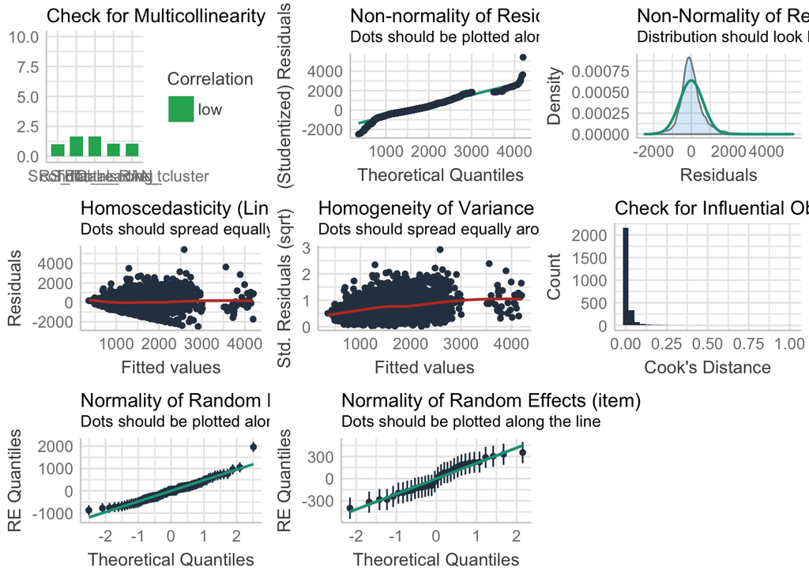

```r
#anova(model_alldatacov_R4_null, model_alldatacov_R4)
check_model(model_alldatacov_R4)
```

```r
ranef(model_alldatacov_R4)
```

```
## $subj
##    (Intercept)
## 1   -89.887012
## 10 -569.915588
## 11  194.958221
## 12  237.300915
## 13 -255.040008
## 14  -68.994894
## 15 -286.109029
## 16  293.538982
## 17  691.668204
## 18  159.667301
## 19  119.699712
## 2   139.326601
## 20  557.130397
```

[output cut: 107 more lines]